# Practice Final Problems

### Problem 3.

[video not shown]

The Warriors played and won in the 2018 playoffs (reread this sentence a few times over if you’ve not yet understood this). The following contingency table contains information about Steph Curry.

Stephen Curry is a basketball player on the Golden State Warriors (GSW) well-known for his impressive 3 point shot. During the 2018 playoffs, Curry’s performance was jawdropping. Thus, we wanted to set up the following table to inspect some stats. This table contains counts of points corresponding to the last 4 playoff games.

| Points made by | Points scored by 3pt shot | All other points scored | Totals |
| --- | --- | --- | --- |
| Stephen Curry | 66 | 44 | 110 |
| All other Warriors | 87 | y | 354 |
| Totals | 153 | z | x |

#### Part (a)

Based on the above and per your calculations, how many points total did GSW score during these 4 games?

```r
110+354
```

```
## [1] 464
```

#### Part (b)

What is the probability that Stephen Curry scored points from a 3 point shot?  
This is $P(\text{3 point shot}|\text{Steph})$.

```r
n_steph     <- 110
n_steph_3pt <- 66

n_steph_3pt / n_steph
```

```
## [1] 0.6
```

#### Part (c)

What is the probability of all other Warriors scoring points from a 3 point shot?

```r
87/354
```

```
## [1] 0.2457627
```

#### Part (d)

Which probability does the value of $y/z$ from the table represent?

**ANSWER** $\, \, \text{A.} \, \,$ Points were made by all other Warriors given the points were not scored from 3 point shots

$\bigcirc \, \, \text{B.} \, \,$ Points scored were not from 3 point shots and the points were scored by all other Warriors

$\bigcirc \, \, \text{C.} \, \,$ Points scored were not from 3 point shots given the points were scored by all other Warriors

### Problem 4.

Arya and Brienne are both awesome warriors. They took upon themselves to take on students. As a competition, they tested their students and gave them a battle competency grade (out of 100).

This is a preview of the dataset.

| variable | value |
| --- | --- |
| brienne | 80.77851 |
| arya | 56.30703 |
| arya | 74.11349 |
| arya | 55.52089 |
| brienne | 96.76028 |
| brienne | 83.20172 |
| brienne | 85.82450 |

#### Part (a)

**What kind of plot is this?**

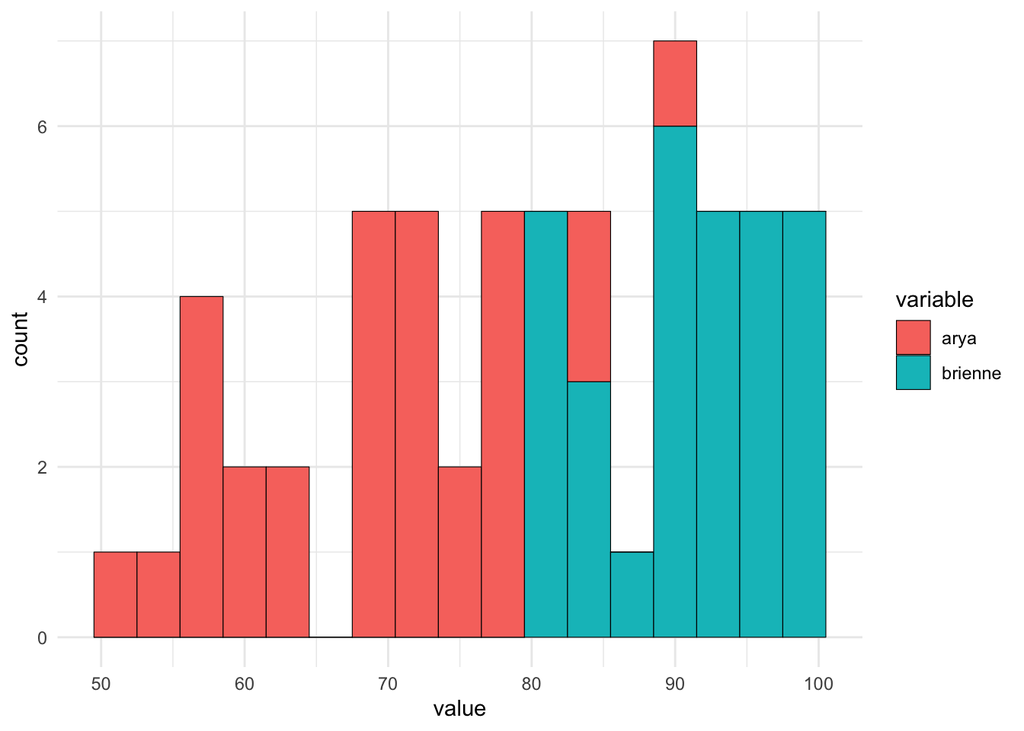

Histogram or overlapping histogram. (It’s not dodged :P).

#### Part (b)

**What kind of plot is this?**

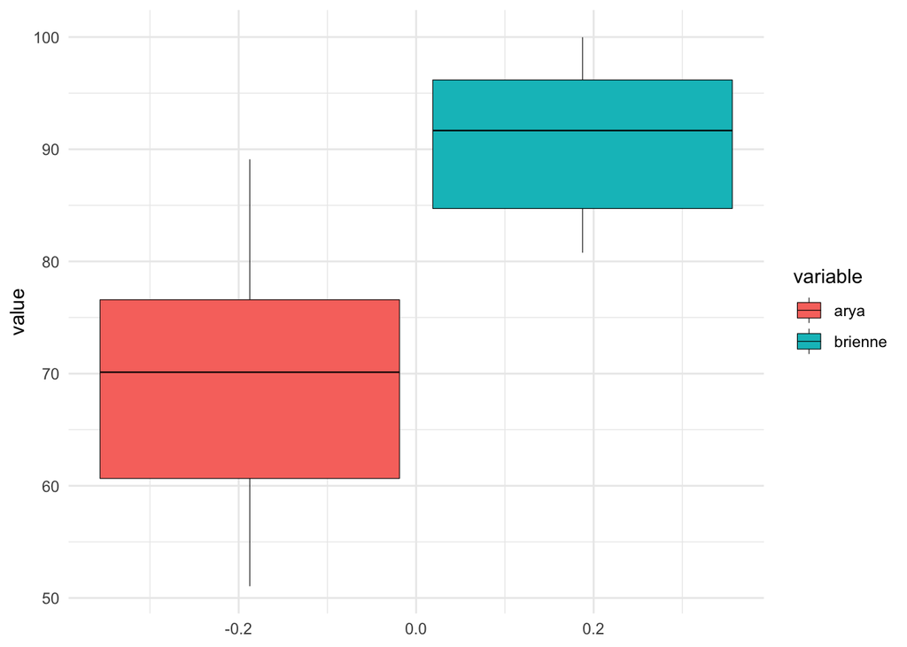

Dodged boxplot.

**We are interested in testing whether Arya’s students or Brienne’s students are more combat competent.**